# A mixed model example from HW5

## Exploring our homework data!

Here we’ll try working with the data from homework 5 (that was also used in the tutorial in Week 0 if you were there!) to get used to using mixed models.

Let’s read about our data in `kv0.csv`!

This is a *repeated measures design*.

The question we want to answer is: **How does score depend on attention and number of possible solutions?**

Variables:

- **subidr**: Subject ID
- **attnr**: 1 = divided attention condition; 2 = focused attention condition
- **num1**: only one solution to the anagram
- **num2**: two possible solutions to the anagram
- **num3**: three possible solutions to the anagram

Let’s read in our data!

```r
library(ggplot2)
library(lme4)
d0 <- read.csv('http://www.stanford.edu/class/psych252/data/kv0.csv')

str(d0)
```

```
## 'data.frame':    20 obs. of  5 variables:
##  $ subidr: int  1 2 3 4 5 6 7 8 9 10 ...
##  $ attnr : Factor w/ 2 levels "divided","focused": 1 1 1 1 1 1 1 1 1 1 ...
##  $ num1  : int  2 3 3 5 4 5 5 5 2 6 ...
##  $ num2  : num  4 4 5 7 5 5 4.5 7 3 5 ...
##  $ num3  : int  7 5 6 5 8 6 6 8 7 6 ...
```

```r
# Make sure to factor subject!
d0$subidr = factor(d0$subidr)
```

### Converting to “long-form”"

Note that our data is in *wide* or *short-form*: `'data.frame': 20 obs. of 5 variables`

By short-form, we mean that the within-subject observations are displayed in separate columns, and each subject occupies a single row.

We need the data in *long-form* for `lmer`. The function `reshape` is an economic way to convert between wide and long formats.

```r
d1 <- reshape(d0, direction="long",
              idvar="subidr",
              varying=list(c("num1","num2","num3")),
              timevar="num", v.names="score" )

head(d1)
```

```
##     subidr   attnr num score
## 1.1      1 divided   1     2
## 2.1      2 divided   1     3
## 3.1      3 divided   1     3
## 4.1      4 divided   1     5
## 5.1      5 divided   1     4
## 6.1      6 divided   1     5
```

```r
str(d1)
```

```
## 'data.frame':    60 obs. of  4 variables:
##  $ subidr: Factor w/ 20 levels "1","2","3","4",..: 1 2 3 4 5 6 7 8 9 10 ...
##  $ attnr : Factor w/ 2 levels "divided","focused": 1 1 1 1 1 1 1 1 1 1 ...
##  $ num   : int  1 1 1 1 1 1 1 1 1 1 ...
##  $ score : num  2 3 3 5 4 5 5 5 2 6 ...
##  - attr(*, "reshapeLong")=List of 4
##   ..$ varying:List of 1
##   .. ..$ : chr  "num1" "num2" "num3"
##   ..$ v.names: chr "score"
##   ..$ idvar  : chr "subidr"
##   ..$ timevar: chr "num"
```

Now the data is in long form: `'data.frame': 60 obs. of 4 variables`

The number of observations that we have in long format is equal to the number of observations in wide format times the product of levels of the repeated measures (within) variables.

In this case we only have one within subject variable with 3 levels (number of possible solutions = 1, 2, or 3), so 20 * 3 = 60 observations

The added variables are identifiers now.

We can also use the function `melt()` from the `reshape2` package to get our data into long form.

Our `id.vars` are those variables that we want to be the same for each subject, and the `measure.vars` are those that are repeated measures on each subject:

```r
# install.packages('reshape2')
library(reshape2)

dl <- melt(d0, id.vars = c("subidr", "attnr"),
           measure.vars = c("num1", "num2", "num3"))

head(dl) # note 'variable' and 'value' names not specified
```

```
##   subidr   attnr variable value
## 1      1 divided     num1     2
## 2      2 divided     num1     3
## 3      3 divided     num1     3
## 4      4 divided     num1     5
## 5      5 divided     num1     4
## 6      6 divided     num1     5
```

```r
colnames(dl) <- c("id", "attn", "num", "score")
head(dl)
```

```
##   id    attn  num score
## 1  1 divided num1     2
## 2  2 divided num1     3
## 3  3 divided num1     3
## 4  4 divided num1     5
## 5  5 divided num1     4
## 6  6 divided num1     5
```

```r
str(dl)
```

```
## 'data.frame':    60 obs. of  4 variables:
##  $ id   : Factor w/ 20 levels "1","2","3","4",..: 1 2 3 4 5 6 7 8 9 10 ...
##  $ attn : Factor w/ 2 levels "divided","focused": 1 1 1 1 1 1 1 1 1 1 ...
##  $ num  : Factor w/ 3 levels "num1","num2",..: 1 1 1 1 1 1 1 1 1 1 ...
##  $ score: num  2 3 3 5 4 5 5 5 2 6 ...
```

It has also become increasingly standard to use the `gather()` function from the `tidyr` package to get data into long form. `tidyr` was written by Hadley Wickem (author of `ggplot` and `dplyr`), and many people prefer to stay within this cluster of packages, since they share similar syntax and work nicely with one another.

```r
# install.packages('reshape2')
library(tidyr)
dl_alt <- gather(d0,
                 num, score, # name of new key, values columns
                 num1, num2, num3) # columns you want to gather up

str(dl_alt) # note 'variable' and 'value' names not specified
```

```
## 'data.frame':    60 obs. of  4 variables:
##  $ subidr: Factor w/ 20 levels "1","2","3","4",..: 1 2 3 4 5 6 7 8 9 10 ...
##  $ attnr : Factor w/ 2 levels "divided","focused": 1 1 1 1 1 1 1 1 1 1 ...
##  $ num   : Factor w/ 3 levels "num1","num2",..: 1 1 1 1 1 1 1 1 1 1 ...
##  $ score : num  2 3 3 5 4 5 5 5 2 6 ...
```

However you want to do it, we now have a long-form dataframe with 3 rows for each subject.

### Some data preprocessing

Since the levels of ‘num’ were created from the original column names (i.e., num1, num2, num3), R interprets the ‘num’ variable as a factor. However, if we want to treat num as a quantitative variable, we need to force num to be numeric. Whether you treat it as a factor or not depends on many factors, so we’ll leave you to decide which to use for HW5! We also want the subject id (‘id’) to be a factor:

```r
dl$num <- as.numeric(dl$num)
dl$id <- factor(dl$id)
```

Rename var to be subj

```r
dl$subj.id <- factor(dl$id)
head(dl)
```

```
##   id    attn num score subj.id
## 1  1 divided   1     2       1
## 2  2 divided   1     3       2
## 3  3 divided   1     3       3
## 4  4 divided   1     5       4
## 5  5 divided   1     4       5
## 6  6 divided   1     5       6
```

Now that we have our dataset ready to go, try plotting the data, and creating and comparing some mixed models using this data.

There are some hints and suggested analyses at the bottom of this document, but try to explore on your own, create your own R script and then compare! Feel free to work with anyone sitting around you.

### Plotting the data

Let’s visualize what we’re modeling with the random intercept model.

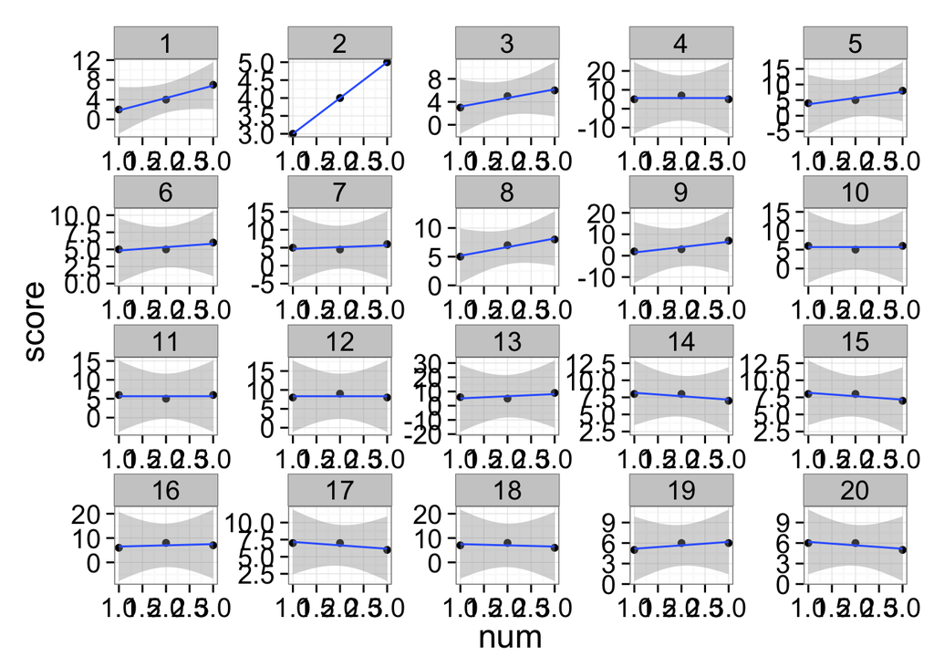

```r
library(ggplot2)
theme_set(theme_bw(base_size = 18))
ggplot(dl, aes(x=num, y=score)) +
     #tell ggplot what data is, and x and y variables
     facet_wrap(~subj.id, ncol=5, scales='free') +
     #add a wrapping by unique combos of 2 variable
     #set num columns, and vary scales per facet.
     geom_point()+
     #add the points as representations
     stat_smooth(method='lm', aes(group=1))
```

```r
     #add the linear fits.
```

### Possible analyses

Start with a simple regression and random intercept for subject

```r
library(lme4)
library(lmerTest)
res1 = lmer(score ~ num + (1|subj.id), dl)
summary(res1)
```

```
## Linear mixed model fit by REML ['merModLmerTest']
## Formula: score ~ num + (1 | subj.id)
##    Data: dl
##
## REML criterion at convergence: 214.3
##
## Scaled residuals:
##     Min      1Q  Median      3Q     Max
## -1.8882 -0.6390 -0.0861  0.7287  1.6482
##
## Random effects:
##  Groups   Name        Variance Std.Dev.
##  subj.id  (Intercept) 1.04     1.02
##  Residual             1.40     1.19
## Number of obs: 60, groups:  subj.id, 20
##
## Fixed effects:
##             Estimate Std. Error     df t value Pr(>|t|)
## (Intercept)    4.758      0.465 57.900    10.2  1.3e-14 ***
## num            0.600      0.187 39.000     3.2   0.0027 **
## ---
## Signif. codes:  0 '***' 0.001 '**' 0.01 '*' 0.05 '.' 0.1 ' ' 1
##
## Correlation of Fixed Effects:
##     (Intr)
## num -0.807
```

The regression is signifiant and interpretable as usual

Regression equation:

$score$ = 4.76 + .6 * $num$

```r
coef(res1)
```

```
## $subj.id
##    (Intercept) num
## 1        3.638 0.6
## 2        3.408 0.6
## 3        3.867 0.6
## 4        4.557 0.6
## 5        4.557 0.6
## 6        4.327 0.6
## 7        4.212 0.6
## 8        5.247 0.6
## 9        3.408 0.6
## 10       4.557 0.6
## 11       4.557 0.6
## 12       6.396 0.6
## 13       5.247 0.6
## 14       5.937 0.6
## 15       5.937 0.6
## 16       5.477 0.6
## 17       5.247 0.6
## 18       5.477 0.6
## 19       4.557 0.6
## 20       4.557 0.6
##
## attr(,"class")
## [1] "coef.mer"
```

Note that the intercepts for every subject are at slightly different score levels (i.e., the estimated means are different). However, looking at the plots, we see that there is even more variability in the **slopes** of the lines. We can capture those with another random effects term for a random slope.

Random intercept and random slope model:

```r
res2 = lmer(score ~ num + (1 + num|subj.id), dl)
summary(res2)
```

```
## Linear mixed model fit by REML ['merModLmerTest']
## Formula: score ~ num + (1 + num | subj.id)
##    Data: dl
##
## REML criterion at convergence: 201.8
##
## Scaled residuals:
##    Min     1Q Median     3Q    Max
## -1.480 -0.522 -0.106  0.522  2.211
##
## Random effects:
##  Groups   Name        Variance Std.Dev. Corr
##  subj.id  (Intercept) 6.650    2.579
##           num         0.612    0.782    -0.97
##  Residual             0.808    0.899
## Number of obs: 60, groups:  subj.id, 20
##
## Fixed effects:
##             Estimate Std. Error     df t value Pr(>|t|)
## (Intercept)    4.758      0.653 19.000    7.28  6.6e-07 ***
## num            0.600      0.225 19.000    2.66    0.015 *
## ---
## Signif. codes:  0 '***' 0.001 '**' 0.01 '*' 0.05 '.' 0.1 ' ' 1
##
## Correlation of Fixed Effects:
##     (Intr)
## num -0.942
```

The correlation between our random intercepts and slopes for `num` is basically -1 – as our intercepts get higher, the slope gets smaller. This is a little suspicious…

```r
# correlation between intercept and slope
data_coefs = data.frame(coef(res2)$subj.id)
colnames(data_coefs) = c('int', 'num')
str(data_coefs)
```

```
## 'data.frame':    20 obs. of  2 variables:
##  $ int: num  0.766 1.766 2.173 4.948 3.022 ...
##  $ num: num  1.817 1.349 1.335 0.461 1.22 ...
```

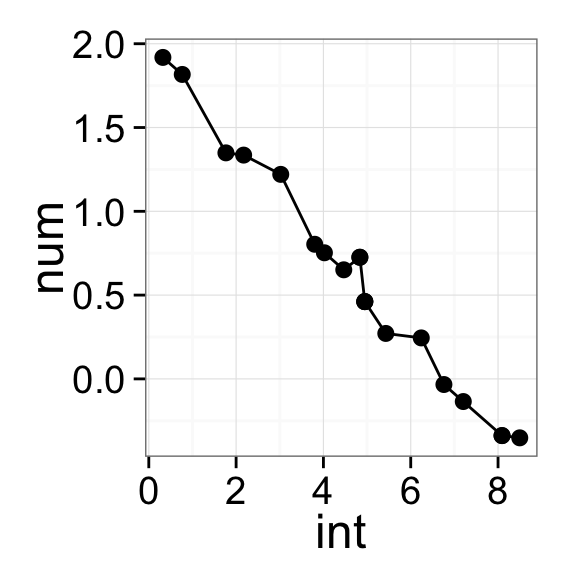

```r
ggplot(data=data_coefs, aes(x=int, y=num)) +
  geom_point(size=3) + geom_line()
```

Note that we now have more coefficients in the random effects table and our main effects have reduced in significance.

```r
anova(res1, res2, refit=FALSE)
```

```
## Data: dl
## Models:
## object: score ~ num + (1 | subj.id)
## ..1: score ~ num + (1 + num | subj.id)
##        Df AIC BIC logLik deviance Chisq Chi Df Pr(>Chisq)
## object  4 222 231   -107      214
## ..1     6 214 226   -101      202  12.5      2      0.002 **
## ---
## Signif. codes:  0 '***' 0.001 '**' 0.01 '*' 0.05 '.' 0.1 ' ' 1
```

It seems like the model with the random slope does account for significantly more variance! Now you have a research and/or moral dilemma. Do you try to figure out what’s causing the variance in slope and intercept? Do you push the simpler but worse model? Or, could there be something else going on?

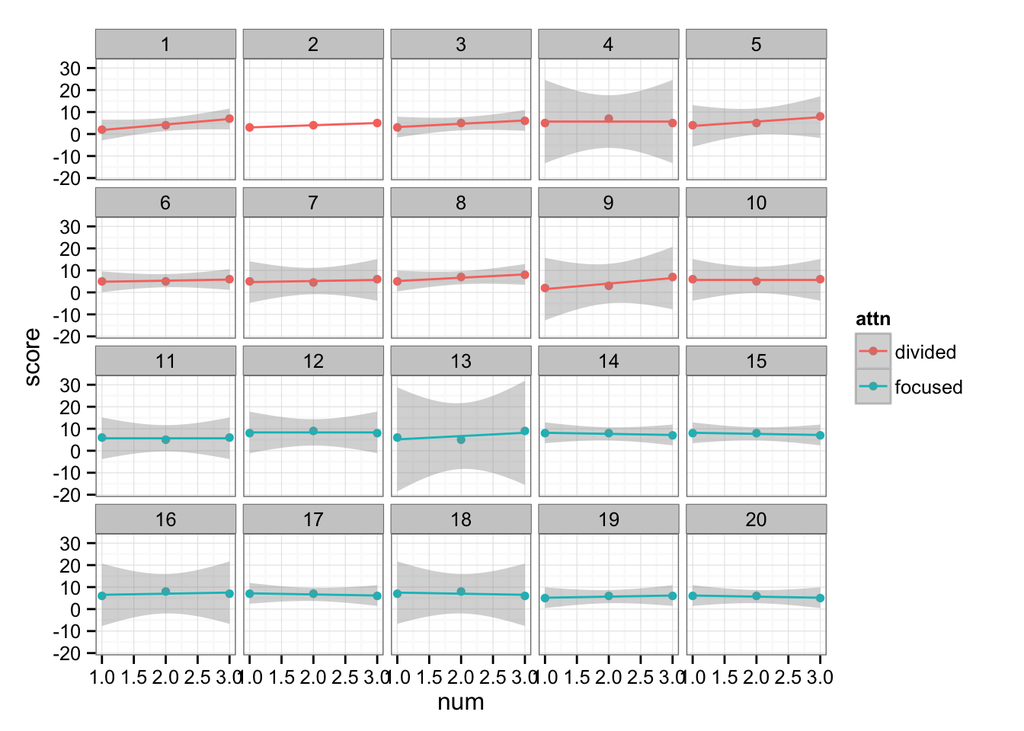

```r
ggplot(dl, aes(x=num, y=score, cond=attn, color=attn)) +
     facet_wrap(~subj.id, ncol=5, scales='fixed')+
     geom_point()+theme_bw()+
     stat_smooth(method='lm')
```

```r
# Set up contrast for attention
contrasts(dl$attn) = c(-1, 1)
contrasts(dl$attn)
```

```
##         [,1]
## divided   -1
## focused    1
```

```r
res3a = lmer(score ~ scale(num, scale=FALSE) + attn + (1|subj.id), REML=FALSE, dl)
summary(res3a)
```

```
## Linear mixed model fit by maximum likelihood  ['merModLmerTest']
## Formula: score ~ scale(num, scale = FALSE) + attn + (1 | subj.id)
##    Data: dl
##
##      AIC      BIC   logLik deviance df.resid
##    208.4    218.8    -99.2    198.4       55
##
## Scaled residuals:
##     Min      1Q  Median      3Q     Max
## -1.9030 -0.6288 -0.0247  0.7514  1.7774
##
## Random effects:
##  Groups   Name        Variance Std.Dev.
##  subj.id  (Intercept) 0.268    0.518
##  Residual             1.369    1.170
## Number of obs: 60, groups:  subj.id, 20
##
## Fixed effects:
##                           Estimate Std. Error     df t value Pr(>|t|)
## (Intercept)                  5.958      0.190 20.000   31.30  < 2e-16 ***
## scale(num, scale = FALSE)    0.600      0.185 40.000    3.24  0.00239 **
## attn1                        0.842      0.190 20.000    4.42  0.00026 ***
## ---
## Signif. codes:  0 '***' 0.001 '**' 0.01 '*' 0.05 '.' 0.1 ' ' 1
##
## Correlation of Fixed Effects:
##             (Intr) s(,s=F
## s(,s=FALSE) 0.000
## attn1       0.000  0.000
```

```r
res3b = lmer(score ~ scale(num, scale=FALSE) + (1|subj.id), REML=FALSE, dl)
summary(res3b)
```

```
## Linear mixed model fit by maximum likelihood  ['merModLmerTest']
## Formula: score ~ scale(num, scale = FALSE) + (1 | subj.id)
##    Data: dl
##
##      AIC      BIC   logLik deviance df.resid
##    220.0    228.4   -106.0    212.0       56
##
## Scaled residuals:
##     Min      1Q  Median      3Q     Max
## -1.9236 -0.6491 -0.0899  0.7499  1.6741
##
## Random effects:
##  Groups   Name        Variance Std.Dev.
##  subj.id  (Intercept) 0.977    0.988
##  Residual             1.369    1.170
## Number of obs: 60, groups:  subj.id, 20
##
## Fixed effects:
##                           Estimate Std. Error     df t value Pr(>|t|)
## (Intercept)                  5.958      0.268 20.000   22.26  1.3e-15 ***
## scale(num, scale = FALSE)    0.600      0.185 40.000    3.24   0.0024 **
## ---
## Signif. codes:  0 '***' 0.001 '**' 0.01 '*' 0.05 '.' 0.1 ' ' 1
##
## Correlation of Fixed Effects:
##             (Intr)
## s(,s=FALSE) 0.000
```

```r
anova(res3b, res3a)
```

```
## Data: dl
## Models:
## object: score ~ scale(num, scale = FALSE) + (1 | subj.id)
## ..1: score ~ scale(num, scale = FALSE) + attn + (1 | subj.id)
##        Df AIC BIC logLik deviance Chisq Chi Df Pr(>Chisq)
## object  4 220 228 -106.0      212
## ..1     5 208 219  -99.2      198  13.6      1    0.00022 ***
## ---
## Signif. codes:  0 '***' 0.001 '**' 0.01 '*' 0.05 '.' 0.1 ' ' 1
```

Including attn in the model significantly improves model fit.

```r
res4b = lmer(score ~ scale(num, scale=FALSE) + attn + (1 + num|subj.id), REML=TRUE, dl)
summary(res4b)
```

```
## Linear mixed model fit by REML ['merModLmerTest']
## Formula: score ~ scale(num, scale = FALSE) + attn + (1 + num | subj.id)
##    Data: dl
##
## REML criterion at convergence: 197
##
## Scaled residuals:
##     Min      1Q  Median      3Q     Max
## -1.7062 -0.4920 -0.0439  0.4469  1.5464
##
## Random effects:
##  Groups   Name        Variance Std.Dev. Corr
##  subj.id  (Intercept) 4.357    2.087
##           num         0.612    0.782    -0.95
##  Residual             0.808    0.899
## Number of obs: 60, groups:  subj.id, 20
##
## Fixed effects:
##                           Estimate Std. Error     df t value Pr(>|t|)
## (Intercept)                  5.958      0.205 16.140   29.03  2.2e-15 ***
## scale(num, scale = FALSE)    0.600      0.225 19.000    2.66   0.0154 *
## attn1                        0.644      0.191 17.990    3.37   0.0034 **
## ---
## Signif. codes:  0 '***' 0.001 '**' 0.01 '*' 0.05 '.' 0.1 ' ' 1
##
## Correlation of Fixed Effects:
##             (Intr) s(,s=F
## s(,s=FALSE) -0.362
## attn1        0.000  0.000
```

```r
coef(res4b)
```

```
## $subj.id
##         num (Intercept) scale(num, scale = FALSE)  attn1
## 1   1.20859       2.691                       0.6 0.6441
## 2   0.45571       4.168                       0.6 0.6441
## 3   0.60573       4.229                       0.6 0.6441
## 4  -0.38943       7.033                       0.6 0.6441
## 5   0.69517       4.621                       0.6 0.6441
## 6  -0.05771       6.098                       0.6 0.6441
## 7  -0.02742       5.932                       0.6 0.6441
## 8   0.24232       6.219                       0.6 0.6441
## 9   1.26916       2.359                       0.6 0.6441
## 10 -0.38943       7.033                       0.6 0.6441
## 11 -0.15534       5.750                       0.6 0.6441
## 12 -0.63988       8.405                       0.6 0.6441
## 13  0.47641       4.937                       0.6 0.6441
## 14 -0.78990       8.344                       0.6 0.6441
## 15 -0.78990       8.344                       0.6 0.6441
## 16 -0.12646       6.475                       0.6 0.6441
## 17 -0.60819       7.349                       0.6 0.6441
## 18 -0.66876       7.680                       0.6 0.6441
## 19  0.11581       5.147                       0.6 0.6441
## 20 -0.42649       6.353                       0.6 0.6441
##
## attr(,"class")
## [1] "coef.mer"
```

```r
res4c = lmer(score ~ scale(num, scale=FALSE) + attn + (1 + attn|subj.id), REML=TRUE, dl)
summary(res4c)
```

```
## summary from lme4 is returned
## some computational error has occurred in lmerTest
```

```
## Linear mixed model fit by REML ['merModLmerTest']
## Formula: score ~ scale(num, scale = FALSE) + attn + (1 + attn | subj.id)
##    Data: dl
##
## REML criterion at convergence: 202.8
##
## Scaled residuals:
##     Min      1Q  Median      3Q     Max
## -1.8470 -0.6437 -0.0785  0.7104  1.7326
##
## Random effects:
##  Groups   Name        Variance Std.Dev. Corr
##  subj.id  (Intercept) 0.000    0.000
##           attn1       0.337    0.581     NaN
##  Residual             1.404    1.185
## Number of obs: 60, groups:  subj.id, 20
##
## Fixed effects:
##                           Estimate Std. Error t value
## (Intercept)                  5.958      0.201    29.7
## scale(num, scale = FALSE)    0.600      0.187     3.2
## attn1                        0.842      0.201     4.2
##
## Correlation of Fixed Effects:
##             (Intr) s(,s=F
## s(,s=FALSE) 0.000
## attn1       0.000  0.000
## convergence code: 0
## unable to evaluate scaled gradient
## Model failed to converge: degenerate  Hessian with 1 negative eigenvalues
```

```r
coef(res4c)
```

```
## $subj.id
##    (Intercept) scale(num, scale = FALSE)  attn1
## 1        5.958                       0.6 1.1696
## 2        5.958                       0.6 1.3091
## 3        5.958                       0.6 1.0300
## 4        5.958                       0.6 0.6114
## 5        5.958                       0.6 0.6114
## 6        5.958                       0.6 0.7510
## 7        5.958                       0.6 0.8207
## 8        5.958                       0.6 0.1929
## 9        5.958                       0.6 1.3091
## 10       5.958                       0.6 0.6114
## 11       5.958                       0.6 0.3673
## 12       5.958                       0.6 1.4835
## 13       5.958                       0.6 0.7859
## 14       5.958                       0.6 1.2044
## 15       5.958                       0.6 1.2044
## 16       5.958                       0.6 0.9254
## 17       5.958                       0.6 0.7859
## 18       5.958                       0.6 0.9254
## 19       5.958                       0.6 0.3673
## 20       5.958                       0.6 0.3673
##
## attr(,"class")
## [1] "coef.mer"
```

```r
res4a = lmer(score ~ scale(num, scale=FALSE) + attn + (1|subj.id), REML=TRUE, dl)
summary(res4a)
```

```
## Linear mixed model fit by REML ['merModLmerTest']
## Formula: score ~ scale(num, scale = FALSE) + attn + (1 | subj.id)
##    Data: dl
##
## REML criterion at convergence: 202.8
##
## Scaled residuals:
##     Min      1Q  Median      3Q     Max
## -1.8470 -0.6437 -0.0785  0.7104  1.7326
##
## Random effects:
##  Groups   Name        Variance Std.Dev.
##  subj.id  (Intercept) 0.337    0.581
##  Residual             1.404    1.185
## Number of obs: 60, groups:  subj.id, 20
##
## Fixed effects:
##                           Estimate Std. Error     df t value Pr(>|t|)
## (Intercept)                  5.958      0.201 18.000    29.7  < 2e-16 ***
## scale(num, scale = FALSE)    0.600      0.187 39.000     3.2  0.00271 **
## attn1                        0.842      0.201 18.000     4.2  0.00054 ***
## ---
## Signif. codes:  0 '***' 0.001 '**' 0.01 '*' 0.05 '.' 0.1 ' ' 1
##
## Correlation of Fixed Effects:
##             (Intr) s(,s=F
## s(,s=FALSE) 0.000
## attn1       0.000  0.000
```

```r
anova(res4a, res4b, refit=FALSE)
```

```
## Data: dl
## Models:
## object: score ~ scale(num, scale = FALSE) + attn + (1 | subj.id)
## ..1: score ~ scale(num, scale = FALSE) + attn + (1 + num | subj.id)
##        Df AIC BIC logLik deviance Chisq Chi Df Pr(>Chisq)
## object  5 213 223 -101.4      203
## ..1     7 211 226  -98.5      197  5.74      2      0.057 .
## ---
## Signif. codes:  0 '***' 0.001 '**' 0.01 '*' 0.05 '.' 0.1 ' ' 1
```

```r
anova(res4a, res4c, refit=FALSE)
```

```
## Data: dl
## Models:
## object: score ~ scale(num, scale = FALSE) + attn + (1 | subj.id)
## ..1: score ~ scale(num, scale = FALSE) + attn + (1 + attn | subj.id)
##        Df AIC BIC logLik deviance Chisq Chi Df Pr(>Chisq)
## object  5 213 223   -101      203
## ..1     7 217 231   -101      203     0      2          1
```

```r
# res4a is still the best! though you could argue that 4b is capturing some variance too...
summary(res4a)
```

```
## Linear mixed model fit by REML ['merModLmerTest']
## Formula: score ~ scale(num, scale = FALSE) + attn + (1 | subj.id)
##    Data: dl
##
## REML criterion at convergence: 202.8
##
## Scaled residuals:
##     Min      1Q  Median      3Q     Max
## -1.8470 -0.6437 -0.0785  0.7104  1.7326
##
## Random effects:
##  Groups   Name        Variance Std.Dev.
##  subj.id  (Intercept) 0.337    0.581
##  Residual             1.404    1.185
## Number of obs: 60, groups:  subj.id, 20
##
## Fixed effects:
##                           Estimate Std. Error     df t value Pr(>|t|)
## (Intercept)                  5.958      0.201 18.000    29.7  < 2e-16 ***
## scale(num, scale = FALSE)    0.600      0.187 39.000     3.2  0.00271 **
## attn1                        0.842      0.201 18.000     4.2  0.00054 ***
## ---
## Signif. codes:  0 '***' 0.001 '**' 0.01 '*' 0.05 '.' 0.1 ' ' 1
##
## Correlation of Fixed Effects:
##             (Intr) s(,s=F
## s(,s=FALSE) 0.000
## attn1       0.000  0.000
```

```r
res5a = lmer(score ~ scale(num, scale=FALSE) + attn + (1|subj.id), REML=FALSE, dl)

res5b = lmer(score ~ scale(num, scale=FALSE) * attn + (1|subj.id), REML=FALSE, dl)

anova(res5a, res5b)
```

```
## Data: dl
## Models:
## object: score ~ scale(num, scale = FALSE) + attn + (1 | subj.id)
## ..1: score ~ scale(num, scale = FALSE) * attn + (1 | subj.id)
##        Df AIC BIC logLik deviance Chisq Chi Df Pr(>Chisq)
## object  5 208 219  -99.2      198
## ..1     6 198 211  -93.1      186  12.2      1    0.00048 ***
## ---
## Signif. codes:  0 '***' 0.001 '**' 0.01 '*' 0.05 '.' 0.1 ' ' 1
```

```r
summary(res5b)
```

```
## Linear mixed model fit by maximum likelihood  ['merModLmerTest']
## Formula: score ~ scale(num, scale = FALSE) * attn + (1 | subj.id)
##    Data: dl
##
##      AIC      BIC   logLik deviance df.resid
##    198.2    210.7    -93.1    186.2       54
##
## Scaled residuals:
##    Min     1Q Median     3Q    Max
## -1.721 -0.648 -0.192  0.732  2.261
##
## Random effects:
##  Groups   Name        Variance Std.Dev.
##  subj.id  (Intercept) 0.388    0.623
##  Residual             1.009    1.005
## Number of obs: 60, groups:  subj.id, 20
##
## Fixed effects:
##                                 Estimate Std. Error     df t value
## (Intercept)                        5.958      0.190 20.000   31.30
## scale(num, scale = FALSE)          0.600      0.159 40.000    3.78
## attn1                              0.842      0.190 20.000    4.42
## scale(num, scale = FALSE):attn1   -0.600      0.159 40.000   -3.78
##                                 Pr(>|t|)
## (Intercept)                      < 2e-16 ***
## scale(num, scale = FALSE)        0.00052 ***
## attn1                            0.00026 ***
## scale(num, scale = FALSE):attn1  0.00052 ***
## ---
## Signif. codes:  0 '***' 0.001 '**' 0.01 '*' 0.05 '.' 0.1 ' ' 1
##
## Correlation of Fixed Effects:
##              (Intr) sc(,s=FALSE) attn1
## sc(,s=FALSE) 0.000
## attn1        0.000  0.000
## s(,s=FALSE): 0.000  0.000        0.000
```

The interaction is significant!

```r
res6a = lmer(score ~ scale(num, scale=FALSE) * attn + (1|subj.id), REML=TRUE, dl)

res6b = lmer(score ~ scale(num, scale=FALSE) * attn + (1+num|subj.id), REML=TRUE, dl)

# Can't do this with this dataset, since attn is not within subject!
# res6c = lmer(score ~ scale(num, scale=FALSE) * attn + (1+attn|subj.id), REML=TRUE, dl)

anova(res6a, res6b, refit=FALSE)
```

```
## Data: dl
## Models:
## object: score ~ scale(num, scale = FALSE) * attn + (1 | subj.id)
## ..1: score ~ scale(num, scale = FALSE) * attn + (1 + num | subj.id)
##        Df AIC BIC logLik deviance Chisq Chi Df Pr(>Chisq)
## object  6 205 217  -96.3      193
## ..1     8 206 222  -94.9      190  2.93      2       0.23
```

```r
# anova(res6a, res6c, refit=FALSE)

summary(res6a) # adding random slopes didn't help much...
```

```
## Linear mixed model fit by REML ['merModLmerTest']
## Formula: score ~ scale(num, scale = FALSE) * attn + (1 | subj.id)
##    Data: dl
##
## REML criterion at convergence: 192.7
##
## Scaled residuals:
##    Min     1Q Median     3Q    Max
## -1.674 -0.630 -0.160  0.693  2.207
##
## Random effects:
##  Groups   Name        Variance Std.Dev.
##  subj.id  (Intercept) 0.451    0.672
##  Residual             1.062    1.031
## Number of obs: 60, groups:  subj.id, 20
##
## Fixed effects:
##                                 Estimate Std. Error     df t value
## (Intercept)                        5.958      0.201 18.000   29.70
## scale(num, scale = FALSE)          0.600      0.163 38.000    3.68
## attn1                              0.842      0.201 18.000    4.20
## scale(num, scale = FALSE):attn1   -0.600      0.163 38.000   -3.68
##                                 Pr(>|t|)
## (Intercept)                      < 2e-16 ***
## scale(num, scale = FALSE)        0.00072 ***
## attn1                            0.00054 ***
## scale(num, scale = FALSE):attn1  0.00072 ***
## ---
## Signif. codes:  0 '***' 0.001 '**' 0.01 '*' 0.05 '.' 0.1 ' ' 1
##
## Correlation of Fixed Effects:
##              (Intr) sc(,s=FALSE) attn1
## sc(,s=FALSE) 0.000
## attn1        0.000  0.000
## s(,s=FALSE): 0.000  0.000        0.000
```

```r
# compare to lm
summary(lm(score ~ scale(num, scale=FALSE) * attn, data=dl))
```

```
##
## Call:
## lm(formula = score ~ scale(num, scale = FALSE) * attn, data = dl)
##
## Residuals:
##    Min     1Q Median     3Q    Max
## -2.117 -0.800 -0.117  1.113  2.200
##
## Coefficients:
##                                 Estimate Std. Error t value Pr(>|t|)
## (Intercept)                        5.958      0.158   37.72  < 2e-16 ***
## scale(num, scale = FALSE)          0.600      0.193    3.10    0.003 **
## attn1                              0.842      0.158    5.33  1.8e-06 ***
## scale(num, scale = FALSE):attn1   -0.600      0.193   -3.10    0.003 **
## ---
## Signif. codes:  0 '***' 0.001 '**' 0.01 '*' 0.05 '.' 0.1 ' ' 1
##
## Residual standard error: 1.22 on 56 degrees of freedom
## Multiple R-squared:  0.46,   Adjusted R-squared:  0.431
## F-statistic: 15.9 on 3 and 56 DF,  p-value: 1.37e-07
```

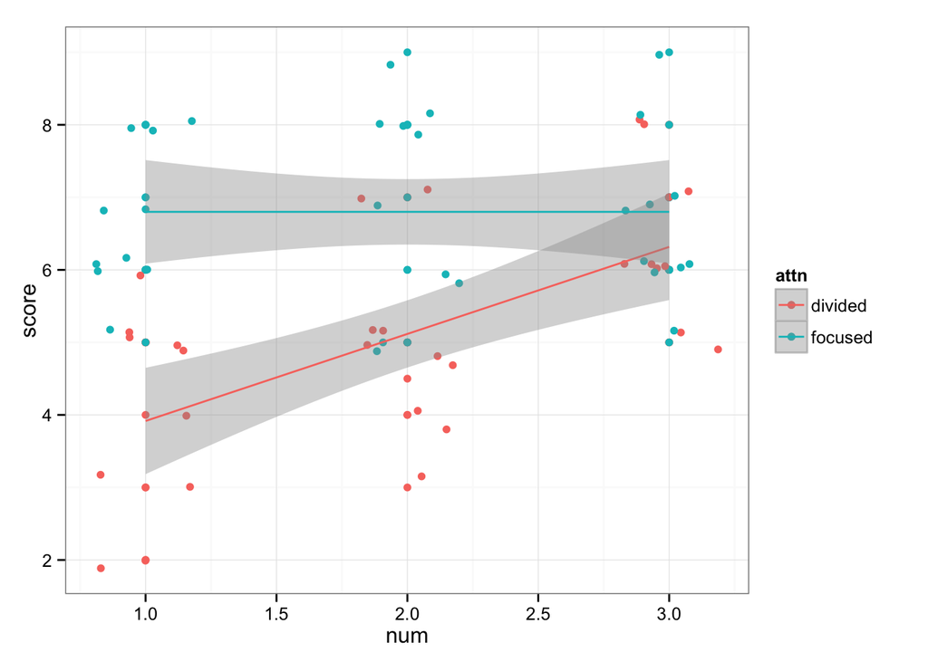

```r
ggplot(dl, aes(x=num, y=score, cond=attn, color=attn)) +
  geom_point()+ theme_bw() +
  geom_jitter(position = position_jitter(width = .2)) +
  stat_smooth(method='lm')
```

There is a significant interaction between number of solutions to the puzzle and attention condition, $t(38) = -3.68, p < 0.01$, such that as the number of solutions to the puzzle decreases (i.e., as the puzzle gets harder) the effect of attention condition on score changes; specifically, when the number of solutions is lowest, divided attention results in a lower score than focused attention. In contrast, when there are more solutions to the puzzle, there is less of a score difference between the divided attention and focused attention conditions.

Note you should also test for simple effects if you want to be thorough!